# Pre and Post WS Open-text Survey Results from April 2022

Arlin Cherian

2022-05-06 (updated: 2022-06-15)

## Overview

This report contains visualizations of open-text survey questions from Pre and Post WS Survey questionnaire. The statistics shown here reflect response from 13 participants who responded to the post-workshop survey and 6 participant responses in pre-workshop survey.

## Pre-Survey Results

Visualizations of all text response questions:

#### Q4: If multiple projects, please describe or type N/A for not applicable?

Key terms from participant personal projects

| Term | Frequency |
| --- | --- |
| project | 7 |
| plan | 3 |
| multiple | 2 |
| team | 2 |
| coordinate | 2 |
| volunteer | 2 |
| community | 2 |
| event | 2 |
| long | 2 |
| term | 2 |
| fund | 2 |
| involve | 1 |
| agile | 1 |
| management | 1 |
| manage | 1 |
| program | 1 |
| schedule | 1 |
| lead | 1 |
| group | 1 |
| committee | 1 |

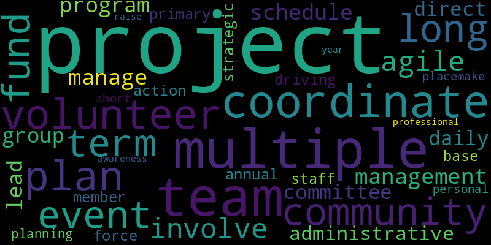

#### Q5: Briefly describe one project (3-5 sentences) that you are currently involved with, or that you anticipate working on in the near future.

Key terms from one participant project

| Term | Frequency |
| --- | --- |
| project | 4 |
| community | 4 |
| phase | 2 |
| renovation | 2 |
| facility | 2 |
| grant | 2 |
| volunteer | 2 |
| wide | 2 |
| need | 2 |
| assessment | 2 |
| uvic | 2 |
| long | 2 |
| fund | 2 |
| migration | 1 |
| try | 1 |
| migrate | 1 |
| access | 1 |
| sophisticated | 1 |
| easy | 1 |
| organization | 1 |

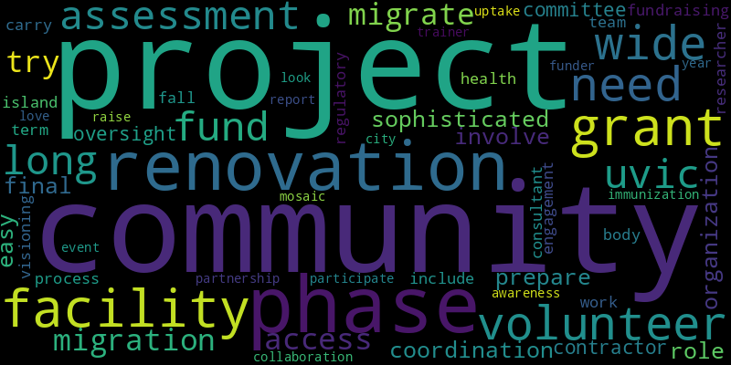

#### Q7: Please describe any areas of TEAM strength you have identified.

Key terms from areas of team strength

| Term | Frequency |
| --- | --- |
| commitment | 2 |
| strategic | 1 |
| analytical | 1 |
| collaborative | 1 |
| project | 1 |
| unify | 1 |
| goal | 1 |
| expertise | 1 |
| relate | 1 |
| field | 1 |
| sure | 1 |
| team | 1 |
| acronym | 1 |
| strength | 1 |
| motivate | 1 |
| involve | 1 |
| ambitious | 1 |
| community | 1 |
| lot | 1 |
| exist | 1 |

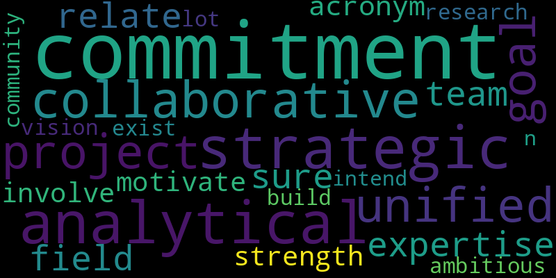

#### Q4: What common and/or recurring issues and challenges do you encounter while being part of a project? (list and briefly describe TOP three if you can)

Key terms related to common areas of challenges in participant projects

| Term | Frequency |
| --- | --- |
| project | 4 |
| timeline | 2 |
| action | 2 |
| request | 2 |
| community | 2 |
| maintain | 1 |
| track | 1 |
| respect | 1 |
| resource | 1 |
| budget | 1 |
| mitigate | 1 |
| risk | 1 |
| adapt | 1 |
| agile | 1 |
| mindset | 1 |
| team | 1 |
| reduce | 1 |
| efficiency | 1 |
| drag | 1 |
| structure | 1 |

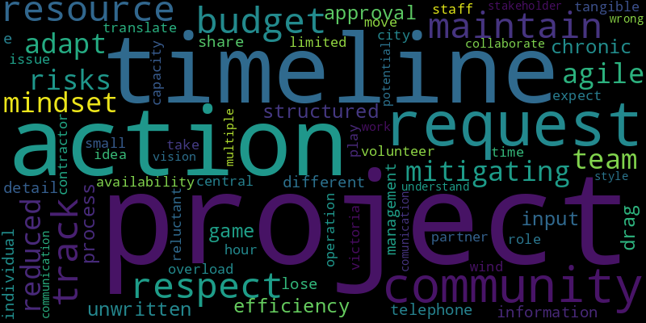

## Post-Survey Results

Visualizations of all open-text responses in Post-workshop survey:

### Content-based questions:

#### Q8: Please describe any recommendations for improvements to this Online Workshop Session?

[figure not shown]

Key terms related to recommendations for improvements to the Online Workshop Session

| Term | Frequency |
| --- | --- |
| project | 4 |
| workshop | 3 |
| time | 3 |
| zoom | 3 |
| work | 2 |
| large | 2 |
| sure | 2 |
| hard | 2 |
| apply | 2 |
| idea | 2 |
| slide | 2 |
| create | 2 |
| break | 2 |
| room | 2 |
| material | 2 |
| think | 2 |
| graphic | 1 |
| don;t | 1 |
| reccomendation | 1 |
| like | 1 |

Phrase-matched terms for workshop session improvement recommendations

| …1 | Frequency |
| --- | --- |
| large organization | 1 |
| sure case | 1 |
| hard time | 1 |
| broad idea | 1 |
| present info | 1 |
| nice update | 1 |
| large group | 1 |
| sure workshop | 1 |
| great chance | 1 |
| mock plan | 1 |
| dynamic activity | 1 |
| apply idea | 1 |
| apply time | 1 |
| create documentation | 1 |
| send zoom | 1 |
| begin break | 1 |
| think example | 1 |
| create project | 1 |
| fill template | 1 |

#### Q9: Please share any other comments relating to this Online Workshop content¶

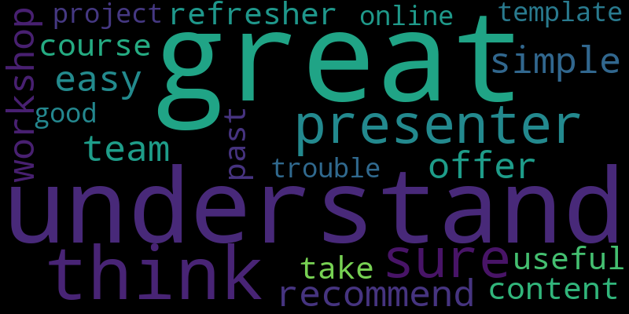

Key terms from online workshop content related comments

| Term | Frequency |
| --- | --- |
| great | 2 |
| understand | 2 |
| think | 2 |
| presenter | 1 |
| sure | 1 |
| recommend | 1 |
| workshop | 1 |
| team | 1 |
| simple | 1 |
| easy | 1 |
| offer | 1 |
| refresher | 1 |
| course | 1 |
| past | 1 |
| NA | 1 |

Phrase-matched terms for workshop session related comments

| …1 | Frequency |
| --- | --- |
| great presenters | 1 |
| next project | 1 |

#### Q12: The “Introduction to Project Management for Non-Profits” workshop is a high-level overview of project management. We are in the process of planning future topics for online workshops.

[figure not shown]

Key terms from online workshop content related comments

| Term | Frequency |
| --- | --- |
| project | 9 |
| management | 5 |
| budget | 4 |
| planning | 3 |
| change | 3 |
| great | 3 |
| different | 3 |
| event | 2 |
| risk | 2 |
| analysis | 2 |
| tool | 2 |
| topic | 2 |
| cost | 2 |
| depth | 2 |
| option | 2 |
| workshop | 2 |
| regular | 2 |
| business | 1 |
| write | 1 |
| leadership | 1 |

Phrase matched terms from online workshop content related comments

| …1 | Frequency |
| --- | --- |
| indepth info | 1 |
| individual event | 1 |
| administrative costs | 1 |
| contractor costs | 1 |
| great option | 1 |
| profits workshop | 1 |
| regular pm | 1 |
| more depth | 1 |
| different pm | 1 |
| other options | 1 |
| more tips | 1 |
| past project | 1 |

#### Q4: Additional comments relating to the Facilitator(s)?

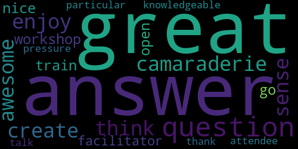

Key terms related to comments about facilitators

| Term | Frequency |
| --- | --- |
| great | 2 |
| answer | 2 |
| question | 2 |
| awesome | 1 |
| think | 1 |
| enjoy | 1 |
| sense | 1 |
| camaraderie | 1 |
| create | 1 |
| workshop | 1 |
| train | 1 |
| nice | 1 |
| open | 1 |
| facilitator | 1 |
| knowledgeable | 1 |
| pressure | 1 |
| attendee | 1 |
| talk | 1 |
| particular | 1 |

Sentiment analysis of comments about workshop facilitators. A positive score between 0 and 1 indicates positive comments, and value between 0 and -1 relates to negative comments.

| facilitator_Comments | polarity |
| --- | --- |
| Awesome! | 1.0000000 |
| nothing :) | 0.5000000 |
| can’t think of anything right now | 0.2857143 |
| I enjoyed the sense of camaraderie that was created in the workshop…we are all in this together. | 0.5000000 |
| Everyone is well trained | 0.0000000 |
| Nice, open and very easy going! | 0.4347222 |
| Nil | 0.0000000 |
| Facilitators were very knowledgeable and great at answering questions. | 0.5000000 |
| They were great, they did not pressure the attendees to talk much or to have to answer any particular question. | 0.3888889 |
| Thank you. | 0.0000000 |

#### Q20: Please describe any recommendations for SLACK that could help connect participants with each other and PMV Facilitators during this session?

Processed version of slack recommendation responses

| …1 | Responses |
| --- | --- |
| 0 | It was fine good |
| 1 | I honestly did use Slack I used the chat and tools in Zoom |
| 2 | I didn’t use slack a lot because our organization used Microsoft teams already which has some similarities. |
| 3 | I didn’t have time to explore slack |
| 4 | I did not like and have never used SLACK plus did not have the time to explore its effectiveness. |
| 5 | Any tool like Miro would be more useful |
| 6 | formulating small groups on the different headings being discussed and share info or experiences in those chats, between the actual class time |
| 8 | Nil |
| 11 | Maybe do an exercise at the beginning involving slack so everyone get used to use it, I know there is the presentations but I mean something more into the workshop itself. |
| 12 | More interactions on there between participants. |

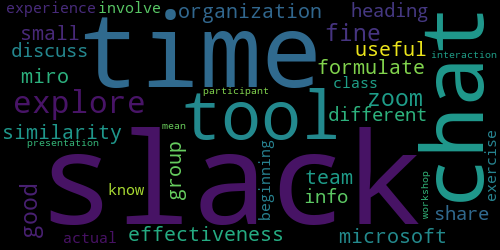

Key terms related to slack recoomendations

| Term | Frequency |
| --- | --- |
| slack | 5 |
| time | 3 |
| chat | 2 |
| tool | 2 |
| explore | 2 |
| fine | 1 |
| good | 1 |
| zoom | 1 |
| organization | 1 |
| microsoft | 1 |
| team | 1 |
| similarity | 1 |
| like | 1 |
| effectiveness | 1 |
| miro | 1 |
| useful | 1 |
| formulate | 1 |
| small | 1 |
| group | 1 |
| different | 1 |

#### Q7: As a volunteer-based organization, PMV does not have an advertising budget so we are always looking for personal comments we can use on our website or social media.

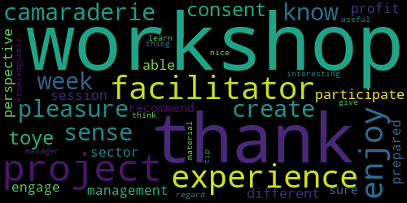

Key terms related to comments regarding website or social media

| Term | Frequency |
| --- | --- |
| workshop | 4 |
| thank | 3 |
| project | 3 |
| enjoy | 2 |
| facilitator | 2 |
| experience | 2 |
| pleasure | 1 |
| know | 1 |
| week | 1 |
| sense | 1 |
| camaraderie | 1 |
| create | 1 |
| consent | 1 |
| toye | 1 |
| participate | 1 |
| able | 1 |
| different | 1 |
| perspective | 1 |
| management | 1 |
| profit | 1 |